# Previsão de Demanda

### Centro do Amazonas

A Figura @ref(fig:MO1401AM001) apresenta o histórico de vendas para este centro.

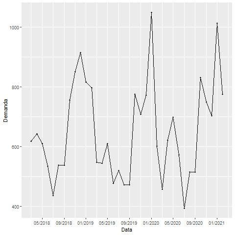

Histório do produto MO1401 no Amazonas

A Figura @ref(fig:MO1401AM002) apresenta a série de forma decomposta em tendência, sazonalidade e restante. Percebe-se pela figura que há uma leve tendência aparentemente linear (nem queda nem aumento na demanda), com uma sazonalidade bastante clara. De fato a tendência se apresenta linear nos últimos meses, mas se recupera de uma tendência de queda no ano de 2019.

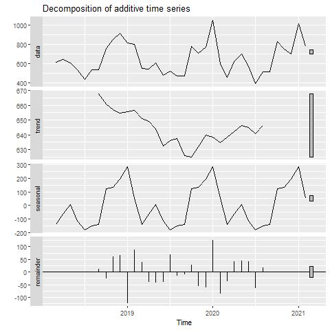

Série decomposta do produto MO1401 no Amazonas

A aplicação dos métodos Suavização Exponencial (SE), ARIMA e Redes Neurais Autoregresivas (RNA) retornou os MAPE’s apresentados na Tabela @ref(tab:TABMO1401AM001).

Comparação entre os modelos

| Método | SE | ARIMA | RNA |
| --- | --- | --- | --- |
| MAPE | 8.06 | 9.44 | 6.24 |

Portanto, por ter o menor MAPE, o método utilizado para a previsão é o de Redes Neurais Artificiais. Ademais, a Figura @ref(fig:MO1401AM003) apresenta a análise de resíduos. Como esperado, os resíduos variam em torno de zero sem tendência positiva ou negativa, o parâmetro ACF (fator de autocorrelação) mostra resultados positivos uma vez que os resíduos não apresentam autocorrelação (as linhas pretas não extrapolam os limites em azul) e os erros apresentam uma característica normal.

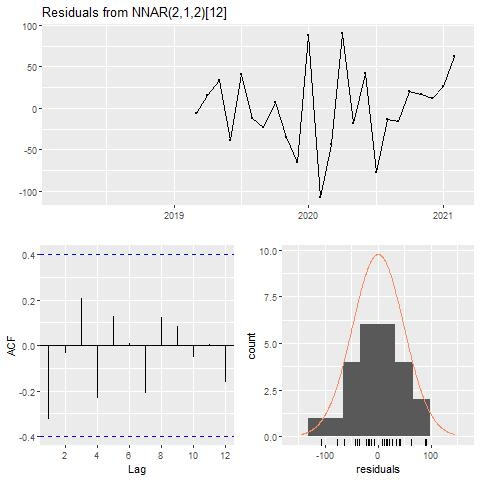

Resíduos da previsão para o produto MO1401 no Amazonas

A Tabela @ref(tab:TABMO1401AM002) apresenta os valores previstos para o ano de 2021.

Previsão de demanda do produto MO1401 para Amazonas

| 03/21 | 04/21 | 05/21 | 06/21 | 07/21 | 08/21 | 09/21 | 10/21 | 11/21 | 12/21 |
| --- | --- | --- | --- | --- | --- | --- | --- | --- | --- |
| 421.42 | 563.55 | 824.7 | 707.77 | 304.13 | 580.02 | 706.72 | 879.59 | 740.36 | 524.94 |

O gráfico da previsão está apresentado na Figura @ref(fig:MO1401AM004).

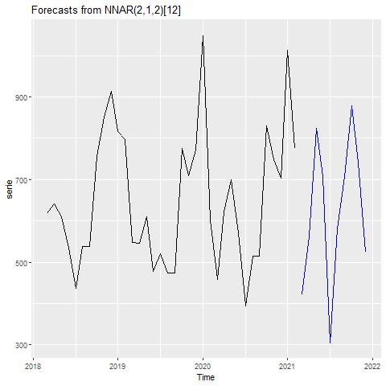

Previsão para o produto MO1401 no Amazonas

## Resultado Final

A Tabela @ref(tab:DEMANDASFINAIS0021) presenta um resumo das demandas finais para o produto MO0021.

Previsão de demanda final para o produto MO0021

| Data | São Paulo | Tocantins | Amazonas |
| --- | --- | --- | --- |
| 03/21 | 265.82 | 1439.50 | 910.99 |
| 04/21 | 231.47 | 885.83 | 1030.59 |
| 05/21 | 228.68 | 1002.20 | 1414.69 |
| 06/21 | 240.97 | 1059.40 | 1281.29 |
| 07/21 | 211.92 | 523.08 | 1053.59 |
| 08/21 | 203.22 | 788.06 | 768.39 |
| 09/21 | 188.37 | 918.39 | 959.29 |
| 10/21 | 186.82 | 987.14 | 910.99 |
| 11/21 | 221.32 | 1060.77 | 881.09 |
| 12/21 | 259.74 | 1166.80 | 759.19 |

Previsão de demanda final para o produto MO0091

| Data | São Paulo | Tocantins | Amazonas |
| --- | --- | --- | --- |
| 03/21 | 1687.10 | 1129.11 | 857.01 |
| 04/21 | 1805.18 | 974.03 | 1132.82 |
| 05/21 | 1810.17 | 1061.11 | 1214.56 |
| 06/21 | 1812.07 | 1592.61 | 1231.73 |
| 07/21 | 1884.44 | 1359.40 | 852.98 |
| 08/21 | 1694.45 | 1285.07 | 760.45 |
| 09/21 | 1302.34 | 1587.77 | 839.24 |
| 10/21 | 1604.99 | 1088.80 | 873.10 |
| 11/21 | 1562.71 | 984.45 | 717.42 |
| 12/21 | 1767.90 | 980.72 | 763.12 |

Por fim, a Tabela @ref(tab:DEMANDASFINAIS1401) presenta um resumo das demandas finais para o produto MO1401.

Previsão de demanda final para o produto MO1401

| Data | São Paulo | Tocantins | Amazonas |
| --- | --- | --- | --- |
| 03/21 | 431.94 | 2034.01 | 421.42 |
| 04/21 | 493.07 | 2460.32 | 563.55 |
| 05/21 | 565.47 | 2865.02 | 824.70 |
| 06/21 | 612.52 | 3099.34 | 707.77 |
| 07/21 | 396.51 | 2683.53 | 304.13 |
| 08/21 | 379.52 | 2526.25 | 580.02 |
| 09/21 | 339.67 | 2093.12 | 706.72 |
| 10/21 | 286.75 | 2014.56 | 879.59 |
| 11/21 | 253.18 | 1955.93 | 740.36 |
| 12/21 | 224.73 | 1576.73 | 524.94 |